# Data Visualization : seaborn

In this tutorial we will explore how to create FacetGrid plots using a plotting tool called 'seaborn'. For that let's first import all the necessary packages:

```python
import seaborn as sns
import numpy as np
import pandas as pd
import matplotlib.pyplot as plt
```

Now suppose for example that you have a team in a company and you'd like to show the expenses of your team members in last week to your boss. How would that look like? Let's explore.

```python
#name of team member:
name = ['Nilesh', 'Yoda', 'Kirk', 'Morpheus', 'Moriarty', 'Albert']
```

```python
#days in a week
day = [0, 1, 2, 3, 4, 5, 6] #Sunday through Saturday
```

Now for your team members, you need to track the expenses on each day. For that, you need to expand your name list, repeating every name 7 time and tiling every day 6 times(for each member)

```python
name = np.repeat(name, 7).tolist() # repeat the names 7 times each and return a list
```

```python
#print the contents of 'name'
name
```

```
['Nilesh',
 'Nilesh',
 'Nilesh',
 'Nilesh',
 'Nilesh',
 'Nilesh',
 'Nilesh',
 'Yoda',
 'Yoda',
 'Yoda',
 'Yoda',
 'Yoda',
 'Yoda',
 'Yoda',
 'Kirk',
 'Kirk',
 'Kirk',
 'Kirk',
 'Kirk',
 'Kirk',
 'Kirk',
 'Morpheus',
 'Morpheus',
 'Morpheus',
 'Morpheus',
 'Morpheus',
 'Morpheus',
 'Morpheus',
 'Moriarty',
 'Moriarty',
 'Moriarty',
 'Moriarty',
 'Moriarty',
 'Moriarty',
 'Moriarty',
 'Albert',
 'Albert',
 'Albert',
 'Albert',
 'Albert',
 'Albert',
 'Albert']
```

Just like we wanted, each name is repeated 7 times.

Now let's tile the week days for each member i.e. 6 times

```python
day = np.tile(day, 6).tolist() # tile the 'day's 6 times and return a list
```

```python
#print day list
day
```

```
[0,
 1,
 2,
 3,
 4,
 5,
 6,
 0,
 1,
 2,
 3,
 4,
 5,
 6,
 0,
 1,
 2,
 3,
 4,
 5,
 6,
 0,
 1,
 2,
 3,
 4,
 5,
 6,
 0,
 1,
 2,
 3,
 4,
 5,
 6,
 0,
 1,
 2,
 3,
 4,
 5,
 6]
```

Using these two lists let's create a dataframe. Before that we need to "zip" these two lists as follows:

```python
np.c_[name, day]
```

```
array([['Nilesh', '0'],
       ['Nilesh', '1'],
       ['Nilesh', '2'],
       ['Nilesh', '3'],
       ['Nilesh', '4'],
       ['Nilesh', '5'],
       ['Nilesh', '6'],
       ['Yoda', '0'],
       ['Yoda', '1'],
       ['Yoda', '2'],
       ['Yoda', '3'],
       ['Yoda', '4'],
       ['Yoda', '5'],
       ['Yoda', '6'],
       ['Kirk', '0'],
       ['Kirk', '1'],
       ['Kirk', '2'],
       ['Kirk', '3'],
       ['Kirk', '4'],
       ['Kirk', '5'],
       ['Kirk', '6'],
       ['Morpheus', '0'],
       ['Morpheus', '1'],
       ['Morpheus', '2'],
       ['Morpheus', '3'],
       ['Morpheus', '4'],
       ['Morpheus', '5'],
       ['Morpheus', '6'],
       ['Moriarty', '0'],
       ['Moriarty', '1'],
       ['Moriarty', '2'],
       ['Moriarty', '3'],
       ['Moriarty', '4'],
       ['Moriarty', '5'],
       ['Moriarty', '6'],
       ['Albert', '0'],
       ['Albert', '1'],
       ['Albert', '2'],
       ['Albert', '3'],
       ['Albert', '4'],
       ['Albert', '5'],
       ['Albert', '6']],
      dtype='<U21')
```

The above array will serve a content for the dataframe

```python
df = pd.DataFrame(np.c_[name, day], columns=['Name','Day'])
```

```python
#print dataframe
df
```

|  | Name | Day |
| --- | --- | --- |
| 0 | Nilesh | 0 |
| 1 | Nilesh | 1 |
| 2 | Nilesh | 2 |
| 3 | Nilesh | 3 |
| 4 | Nilesh | 4 |
| 5 | Nilesh | 5 |
| 6 | Nilesh | 6 |
| 7 | Yoda | 0 |
| 8 | Yoda | 1 |
| 9 | Yoda | 2 |
| 10 | Yoda | 3 |
| 11 | Yoda | 4 |
| 12 | Yoda | 5 |
| 13 | Yoda | 6 |
| 14 | Kirk | 0 |
| 15 | Kirk | 1 |
| 16 | Kirk | 2 |
| 17 | Kirk | 3 |
| 18 | Kirk | 4 |
| 19 | Kirk | 5 |
| 20 | Kirk | 6 |
| 21 | Morpheus | 0 |
| 22 | Morpheus | 1 |
| 23 | Morpheus | 2 |
| 24 | Morpheus | 3 |
| 25 | Morpheus | 4 |
| 26 | Morpheus | 5 |
| 27 | Morpheus | 6 |
| 28 | Moriarty | 0 |
| 29 | Moriarty | 1 |
| 30 | Moriarty | 2 |
| 31 | Moriarty | 3 |
| 32 | Moriarty | 4 |
| 33 | Moriarty | 5 |
| 34 | Moriarty | 6 |
| 35 | Albert | 0 |
| 36 | Albert | 1 |
| 37 | Albert | 2 |
| 38 | Albert | 3 |
| 39 | Albert | 4 |
| 40 | Albert | 5 |
| 41 | Albert | 6 |

But we don't have an expense list for every member on every week day. And we can't have because this is a hypothetical example. So let's just create one randomly

```python
df.shape
```

```
(42, 2)
```

```python
expenses = []
for i in range(6):#for every member
    expenses+=np.random.randint(0,100,7).tolist() #create an expense list of a week out of random numbers
```

```python
len(expenses)
```

```
42
```

This expenses list can be used to create a new column in dataframe

```python
df['Expenses'] = expenses
```

```python
df
```

|  | Name | Day | Expenses |
| --- | --- | --- | --- |
| 0 | Nilesh | 0 | 99 |
| 1 | Nilesh | 1 | 86 |
| 2 | Nilesh | 2 | 88 |
| 3 | Nilesh | 3 | 97 |
| 4 | Nilesh | 4 | 78 |
| 5 | Nilesh | 5 | 51 |
| 6 | Nilesh | 6 | 77 |
| 7 | Yoda | 0 | 49 |
| 8 | Yoda | 1 | 41 |
| 9 | Yoda | 2 | 78 |
| 10 | Yoda | 3 | 64 |
| 11 | Yoda | 4 | 16 |
| 12 | Yoda | 5 | 78 |
| 13 | Yoda | 6 | 17 |
| 14 | Kirk | 0 | 31 |
| 15 | Kirk | 1 | 35 |
| 16 | Kirk | 2 | 34 |
| 17 | Kirk | 3 | 59 |
| 18 | Kirk | 4 | 11 |
| 19 | Kirk | 5 | 45 |
| 20 | Kirk | 6 | 13 |
| 21 | Morpheus | 0 | 64 |
| 22 | Morpheus | 1 | 92 |
| 23 | Morpheus | 2 | 57 |
| 24 | Morpheus | 3 | 84 |
| 25 | Morpheus | 4 | 33 |
| 26 | Morpheus | 5 | 90 |
| 27 | Morpheus | 6 | 2 |
| 28 | Moriarty | 0 | 67 |
| 29 | Moriarty | 1 | 90 |
| 30 | Moriarty | 2 | 18 |
| 31 | Moriarty | 3 | 69 |
| 32 | Moriarty | 4 | 75 |
| 33 | Moriarty | 5 | 70 |
| 34 | Moriarty | 6 | 47 |
| 35 | Albert | 0 | 14 |
| 36 | Albert | 1 | 23 |
| 37 | Albert | 2 | 33 |
| 38 | Albert | 3 | 7 |
| 39 | Albert | 4 | 33 |
| 40 | Albert | 5 | 2 |
| 41 | Albert | 6 | 99 |

So, this is the dataframe you have at our disposal. Using this let's create some Facet plots.

```python
#invoke the FacetGrid class using this dataframe
grid = sns.FacetGrid(df, col='Name', hue='Name', col_wrap=3, size=4.0)
```

let's get a bit of insight into the parameters to this grid:

- 'col' -> which column of dataset is to be considered for facets
- 'hue' -> how to color the plot? By which column? Here a single subplot will have same color for all points but different subplots will have different colors
- 'col_wrap' -> how many subplots to display in a horizontal strip of the plot
- 'size' -> size of the subplot

```python
#draw the horizontal axis at position y=0
grid.map(plt.axhline, y=0, ls="solid", c=".5")
```

the parameters for above grid map specify:

- 'y': the point at which the horizontal axis cuts the y axis
- 'ls': also called linestyle, line design
- 'c': is the color for horizontal line axis. A string of "0" means white while "1" means black. Any float between 0 and 1, as a string, is mixture of black and white.

For more info, run:

```python
help(plt.axhline)
```

[output not shown]

[output cut: 36 more lines]

[output not shown]

```python
df.columns
```

```
Index(['Name', 'Day', 'Expenses'], dtype='object')
```

```python
grid.map(plt.plot, "Day", "Expenses", marker="o", ms=6)
```

For more info, run:

```python
help(plt.plot)
```

[output not shown]

[output cut: 121 more lines]

[output not shown]

some more housekeeping; We encourage you to use the 'help' function in above manner to find out exactly what the following line is doing. It's very easy.

```python
grid.set(xticks=np.arange(7), yticks=np.arange(-10,100,10), xlim=(-1,7), ylim=(-10,100))
```

Again, run help on 'grid.fig.tight_layout' and try to figure out what w_pad = 1 means.

```python
grid.fig.tight_layout(w_pad=1)
```

### Now, all the housekeeping is done; let's plot the grid

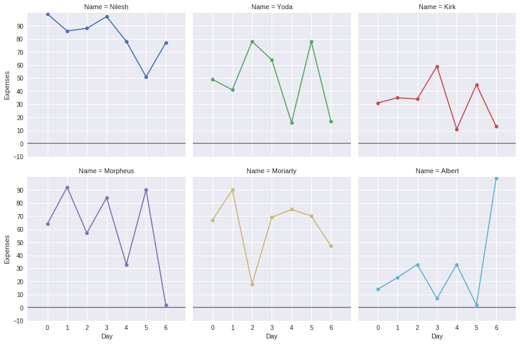

```python
plt.show()
```

Look at those subplots/facets!!

### Now let's play a bit with grid parameters

1) change the col_wrap to 2

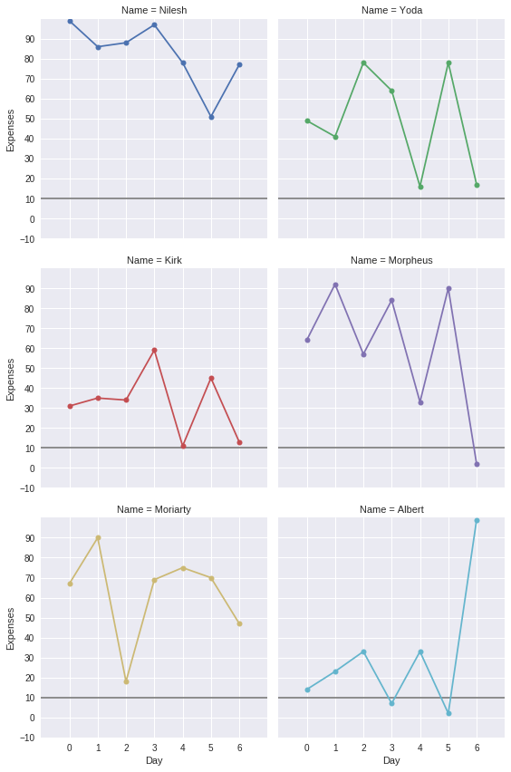

```python
grid = sns.FacetGrid(df, col='Name', hue='Name',col_wrap=2, size=4.0)
grid.map(plt.axhline, y=10, ls="solid", c="0.5")
grid.map(plt.plot, "Day", "Expenses", marker="o", ms=6)
grid.set(xticks=np.arange(7), yticks=np.arange(-10,100,10), xlim=(-1,7), ylim=(-10,100))
grid.fig.tight_layout(w_pad=1)
plt.show()
```

Did you notice the change?

2) change image size from 4 to 3

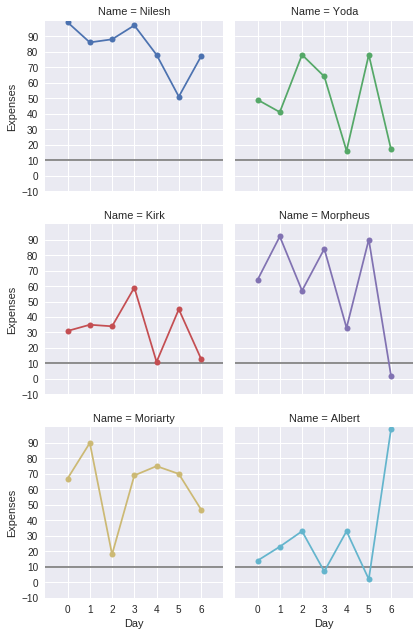

```python
grid = sns.FacetGrid(df, col='Name', hue='Name',col_wrap=2, size=3.0)
grid.map(plt.axhline, y=10, ls="solid", c="0.5")
grid.map(plt.plot, "Day", "Expenses", marker="o", ms=6)
grid.set(xticks=np.arange(7), yticks=np.arange(-10,100,10), xlim=(-1,7), ylim=(-10,100))
grid.fig.tight_layout(w_pad=1)
plt.show()
```

The size of the subplot/facet changes.

3) Now let's try to change the marker style *and* size, and see what happens

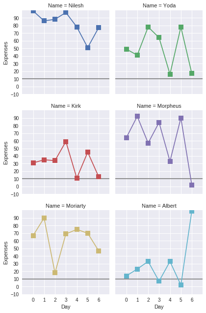

```python
grid = sns.FacetGrid(df, col='Name', hue='Name',col_wrap=2, size=3.0)
grid.map(plt.axhline, y=10, ls="solid", c="0.5")
grid.map(plt.plot, "Day", "Expenses", marker="s", ms=10)
grid.set(xticks=np.arange(7), yticks=np.arange(-10,100,10), xlim=(-1,7), ylim=(-10,100))
grid.fig.tight_layout(w_pad=1)
plt.show()
```

The reader is encouraged to change and play around with each and every parameter of the grid map and observe the effects which might prepare you for future requests.

# Challenge:

There is a subtle difference between the first plot and the subsequent plots. Can you figure it out? I will give you 30 secs.